# Case Study：How Does a Bike-Share Company Navigate Speedy Success?

Fok Zhee Yao

2022-04

## 1. Project Overview

This is a capstone project from Google Data Analytics Certificate, the company below is a fictional company.

### Cyclistic

- A bike sharing company at Chicago with more than 5,800 bicycles and 600 docking stations
- Company offers traditional bikes, reclining bikes, hand tricycles, and cargo bikes
- They have 2 pricing plans, which are annual memberships for **member**, single-ride pass and full-day pass for **casual user**

### Problem

Have to constantly rely on marketing team to bring in new casual users.

### Solution

Convert casual users into members for sustainable growth.

### Analytical Goals

- Identify how **members** and **casual users** use Cyclistic bikes differently
- Recommend how marketing team could strategise marketing campaigns base on primary analytical insights

## 2. Data Source Description

The 12 months dataset I used to conduct the analysis is made available by **[Divvy Data](https://ride.divvybikes.com/system-data)**, from 1st Jan 2021 until 31st Dec 2021.

### Data Limitations

- There is no user data like gender, age, and location for analysis
- Data can only be aggregated on every trip started due to no user ID to track how each individual user behaves
- There is no record on the inventory status of each stations

## 3. Documentation (cleaning & manipulation)

Load the packages needed for this project.

```r
library(tidyverse)
library(lubridate)
library(ggplot2)
library(readr)
library(stringr)
library(dplyr)
library(scales)
```

### Step 1: Collect data

```r
jan_2021 <- read_csv("202101_divvy_tripdata.csv")
feb_2021 <- read_csv("202102_divvy_tripdata.csv")
mar_2021 <- read_csv("202103_divvy_tripdata.csv")
apr_2021 <- read_csv("202104_divvy_tripdata.csv")
may_2021 <- read_csv("202105_divvy_tripdata.csv")
jun_2021 <- read_csv("202106_divvy_tripdata.csv")
jul_2021 <- read_csv("202107_divvy_tripdata.csv")
aug_2021 <- read_csv("202108_divvy_tripdata.csv")
sep_2021 <- read_csv("202109_divvy_tripdata.csv")
oct_2021 <- read_csv("202110_divvy_tripdata.csv")
nov_2021 <- read_csv("202111_divvy_tripdata.csv")
dec_2021 <- read_csv("202112_divvy_tripdata.csv")
```

### Step 2: Wrangle & merge data

Check column consistency.

```r
colnames(jan_2021)
colnames(feb_2021)
colnames(mar_2021)
colnames(apr_2021)
colnames(may_2021)
colnames(jun_2021)
colnames(jul_2021)
colnames(aug_2021)
colnames(sep_2021)
colnames(oct_2021)
colnames(nov_2021)
colnames(dec_2021)
```

Inspect dataframes and check for inconsistency.

```r
str(jan_2021)
str(feb_2021)
str(mar_2021)
str(apr_2021)
str(may_2021)
str(jun_2021)
str(jul_2021)
str(aug_2021)
str(sep_2021)
str(oct_2021)
str(nov_2021)
str(dec_2021)
```

Stack data frame each month into one year big data frame.

```r
tripdata_2021 <- bind_rows(jan_2021,feb_2021,mar_2021,apr_2021,may_2021,jun_2021,jul_2021,aug_2021,sep_2021,oct_2021,nov_2021,dec_2021)
```

### Step 3: Clean and add calculated field for analysis

Inspect new dataframe.

```r
colnames(tripdata_2021)
```

```
##  [1] "ride_id"            "rideable_type"      "started_at"
##  [4] "ended_at"           "start_station_name" "start_station_id"
##  [7] "end_station_name"   "end_station_id"     "start_lat"
## [10] "start_lng"          "end_lat"            "end_lng"
## [13] "member_casual"
```

```r
dim(tripdata_2021)
```

```
## [1] 5595063      13
```

```r
head(tripdata_2021)
```

```
## # A tibble: 6 x 13
##   ride_id rideable_type started_at          ended_at            start_station_n~
##   <chr>   <chr>         <dttm>              <dttm>              <chr>
## 1 E19E6F~ electric_bike 2021-01-23 16:14:19 2021-01-23 16:24:44 California Ave ~
## 2 DC88F2~ electric_bike 2021-01-27 18:43:08 2021-01-27 18:47:12 California Ave ~
## 3 EC45C9~ electric_bike 2021-01-21 22:35:54 2021-01-21 22:37:14 California Ave ~
## 4 4FA453~ electric_bike 2021-01-07 13:31:13 2021-01-07 13:42:55 California Ave ~
## 5 BE5E8E~ electric_bike 2021-01-23 02:24:02 2021-01-23 02:24:45 California Ave ~
## 6 5D8969~ electric_bike 2021-01-09 14:24:07 2021-01-09 15:17:54 California Ave ~
## # ... with 8 more variables: start_station_id <chr>, end_station_name <chr>,
## #   end_station_id <chr>, start_lat <dbl>, start_lng <dbl>, end_lat <dbl>,
## #   end_lng <dbl>, member_casual <chr>
```

```r
summary(tripdata_2021)
```

```
##    ride_id          rideable_type        started_at
##  Length:5595063     Length:5595063     Min.   :2021-01-01 00:02:05
##  Class :character   Class :character   1st Qu.:2021-06-06 23:52:40
##  Mode  :character   Mode  :character   Median :2021-08-01 01:52:11
##                                        Mean   :2021-07-29 07:41:02
##                                        3rd Qu.:2021-09-24 16:36:16
##                                        Max.   :2021-12-31 23:59:48
##
##     ended_at                   start_station_name start_station_id
##  Min.   :2021-01-01 00:08:39   Length:5595063     Length:5595063
##  1st Qu.:2021-06-07 00:44:21   Class :character   Class :character
##  Median :2021-08-01 02:21:55   Mode  :character   Mode  :character
##  Mean   :2021-07-29 08:02:58
##  3rd Qu.:2021-09-24 16:54:05
##  Max.   :2022-01-03 17:32:18
##
##  end_station_name   end_station_id       start_lat       start_lng
##  Length:5595063     Length:5595063     Min.   :41.64   Min.   :-87.84
##  Class :character   Class :character   1st Qu.:41.88   1st Qu.:-87.66
##  Mode  :character   Mode  :character   Median :41.90   Median :-87.64
##                                        Mean   :41.90   Mean   :-87.65
##                                        3rd Qu.:41.93   3rd Qu.:-87.63
##                                        Max.   :42.07   Max.   :-87.52
##
##     end_lat         end_lng       member_casual
##  Min.   :41.39   Min.   :-88.97   Length:5595063
##  1st Qu.:41.88   1st Qu.:-87.66   Class :character
##  Median :41.90   Median :-87.64   Mode  :character
##  Mean   :41.90   Mean   :-87.65
##  3rd Qu.:41.93   3rd Qu.:-87.63
##  Max.   :42.17   Max.   :-87.49
##  NA's   :4771    NA's   :4771
```

```r
unique(tripdata_2021$rideable_type)
```

```
## [1] "electric_bike" "classic_bike"  "docked_bike"
```

```r
View(tripdata_2021)
table(tripdata_2021$member_casual)
```

```
##
##  casual  member
## 2529005 3066058
```

Add columns for aggregation.

```r
tripdata_2021 <- tripdata_2021 %>%
  mutate(date = as.Date(started_at),
         month = month(started_at),
         day_of_week = wday(started_at, label = TRUE),
         trip_duration = round(difftime(ended_at,started_at, units = "mins"),1), #Convert trip duration from seconds to minutes
         time_start = format(started_at,"%H"))
```

Check the new added column.

```r
str(tripdata_2021)
```

```
## tibble [5,595,063 x 18] (S3: tbl_df/tbl/data.frame)
##  $ ride_id           : chr [1:5595063] "E19E6F1B8D4C42ED" "DC88F20C2C55F27F" "EC45C94683FE3F27" "4FA453A75AE377DB" ...
##  $ rideable_type     : chr [1:5595063] "electric_bike" "electric_bike" "electric_bike" "electric_bike" ...
##  $ started_at        : POSIXct[1:5595063], format: "2021-01-23 16:14:19" "2021-01-27 18:43:08" ...
##  $ ended_at          : POSIXct[1:5595063], format: "2021-01-23 16:24:44" "2021-01-27 18:47:12" ...
##  $ start_station_name: chr [1:5595063] "California Ave & Cortez St" "California Ave & Cortez St" "California Ave & Cortez St" "California Ave & Cortez St" ...
##  $ start_station_id  : chr [1:5595063] "17660" "17660" "17660" "17660" ...
##  $ end_station_name  : chr [1:5595063] NA NA NA NA ...
##  $ end_station_id    : chr [1:5595063] NA NA NA NA ...
##  $ start_lat         : num [1:5595063] 41.9 41.9 41.9 41.9 41.9 ...
##  $ start_lng         : num [1:5595063] -87.7 -87.7 -87.7 -87.7 -87.7 ...
##  $ end_lat           : num [1:5595063] 41.9 41.9 41.9 41.9 41.9 ...
##  $ end_lng           : num [1:5595063] -87.7 -87.7 -87.7 -87.7 -87.7 ...
##  $ member_casual     : chr [1:5595063] "member" "member" "member" "member" ...
##  $ date              : Date[1:5595063], format: "2021-01-23" "2021-01-27" ...
##  $ month             : num [1:5595063] 1 1 1 1 1 1 1 1 1 1 ...
##  $ day_of_week       : Ord.factor w/ 7 levels "Sun"<"Mon"<"Tue"<..: 7 4 5 5 7 7 2 5 7 1 ...
##  $ trip_duration     : 'difftime' num [1:5595063] 10.4 4.1 1.3 11.7 ...
##   ..- attr(*, "units")= chr "mins"
##  $ time_start        : chr [1:5595063] "16" "18" "22" "13" ...
```

change trip_duration & time_start to numeric for calculation.

```r
tripdata_2021 <- tripdata_2021 %>%
  mutate(trip_duration = as.numeric(trip_duration),
         time_start = as.numeric(time_start))
```

Convert a numeric month to a month abbreviation.

```r
month_abb <-
c("Jan", "Feb", "Mar", "Apr", "May",
"Jun", "Jul", "Aug", "Sep", "Oct", "Nov", "Dec")
```

Add abbreviated month into dataset.

```r
tripdata_2021$month_new <- month_abb[tripdata_2021$month]
```

Checking for bad data.

```r
max(tripdata_2021$trip_duration)
```

```
## [1] 55944.2
```

```r
min(tripdata_2021$trip_duration)
```

```
## [1] -58
```

There are **negative trip duration** which need to be removed.

```r
bad_trips <- subset(tripdata_2021, trip_duration <0)
```

There are 127 trips have negative duration.

Remove negative trip duration data and save in **tripdata_2021_v2**.

```r
tripdata_2021_v2 <- tripdata_2021 %>%
  filter(trip_duration >= 0)
```

Check for trips that doesn’t make sense, starting with trips between the same start and end station.

```r
duration_checking_same <- filter(tripdata_2021_v2, start_station_name == end_station_name)
```

```r
min(duration_checking_same$trip_duration)
```

```
## [1] 0
```

Notice some trips are less than 1 minute duration travel within the same station, but the **trips with 0 seconds duration** must be removed.

However, we need to find out what is the **reasonable minimum trip duration**, so let’s take trips between 2 different start and end stations for a look.

```r
duration_checking_dif <- filter(tripdata_2021_v2, start_station_name != end_station_name)
```

Look for reasonable trip duration travelling between different & same stations.

```r
trip_dif <-filter(duration_checking_dif, trip_duration <= 0.5)
```

Filter out trips duration above 30 seconds, only left 40 observations found.

The fastest possible trip travelling between 2 stations is 6 seconds and this is the only result, the remaining took **30 seconds**, upon checking on google map, those trips are reasonable.

For example, travel between station Clinton St & Jackson Blvd to station Canal St & Adams St by bike just take 1 minute according to google map.

I will take **30 seconds as a benchmark for each trip duration**, as it doesn’t make sense to ride for just a few seconds.

```r
trip_same <- filter(duration_checking_same, trip_duration <= 0.5)
```

Travel between the same station within 30 seconds has total of 39,090 observations which is 0.6% of the total results.

Now, filter out bad data and remove lat, long, and station id as those data are not useful in the analysis. I save the new dataset in new **tripdata_2021_v3**.

```r
tripdata_2021_v3 <- tripdata_2021 %>%
  filter(trip_duration >= 0.5) %>%
  select(-c(start_station_id,end_station_id,start_lat,end_lat,start_lng,end_lng))
```

## 4. Analysis

Compare the **trip duration** of casual users and members.

```r
# Maximum trip duration
aggregate(data = tripdata_2021_v3, trip_duration ~ member_casual, FUN = max)
```

```
##   member_casual trip_duration
## 1        casual       55944.2
## 2        member        1559.9
```

```r
# Median of trip duration
aggregate(data = tripdata_2021_v3, trip_duration ~ member_casual, FUN = median)
```

```
##   member_casual trip_duration
## 1        casual          16.1
## 2        member           9.7
```

```r
# Average trip duration
aggregate(data = tripdata_2021_v3, trip_duration ~ member_casual, FUN = mean)
```

```
##   member_casual trip_duration
## 1        casual      32.26670
## 2        member      13.77258
```

We can see overall the trip duration of casual users are much longer than members.

Let’s visualize it for a better understanding, first visualize the maximum trip duration by user type.

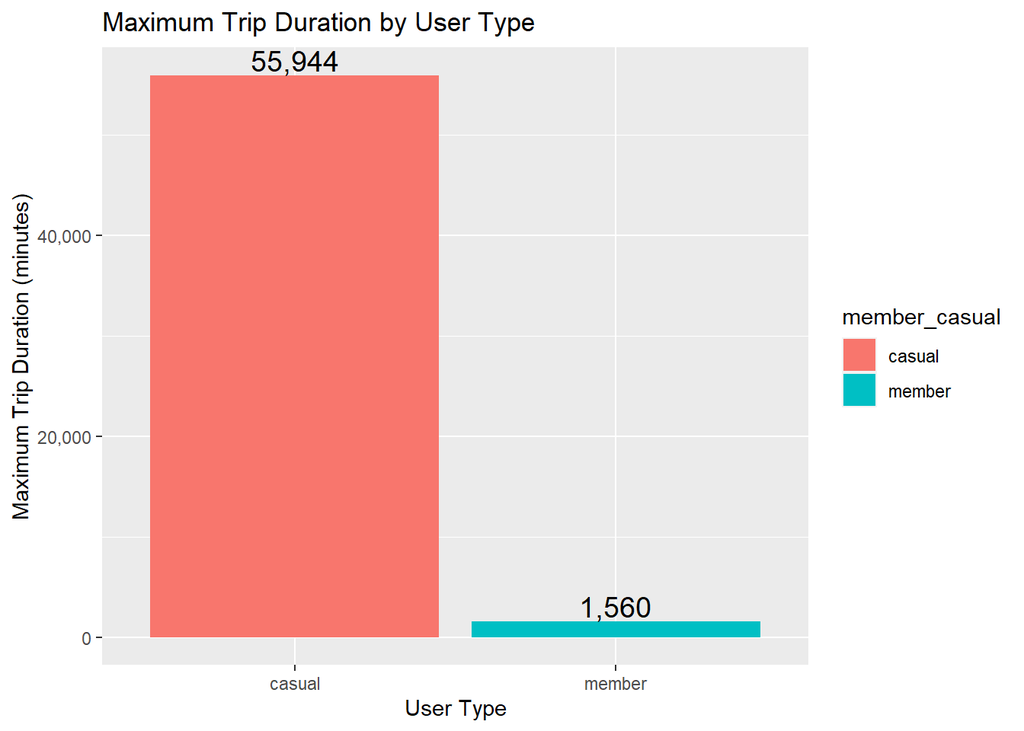

```r
tripdata_2021_v3 %>%
  group_by(member_casual) %>%
  summarise(max_duration = max(trip_duration)) %>%
  ggplot(aes(x = member_casual, y = max_duration, fill = member_casual))+
  geom_col()+
  scale_y_continuous(name = "Maximum Trip Duration (minutes)", labels = comma)+
  labs(title = "Maximum Trip Duration by User Type",x = "User Type")+
  geom_text(aes(label = comma(max_duration)), vjust = -0.2, size = 5)
```

Visualize the median trip duration by user type.

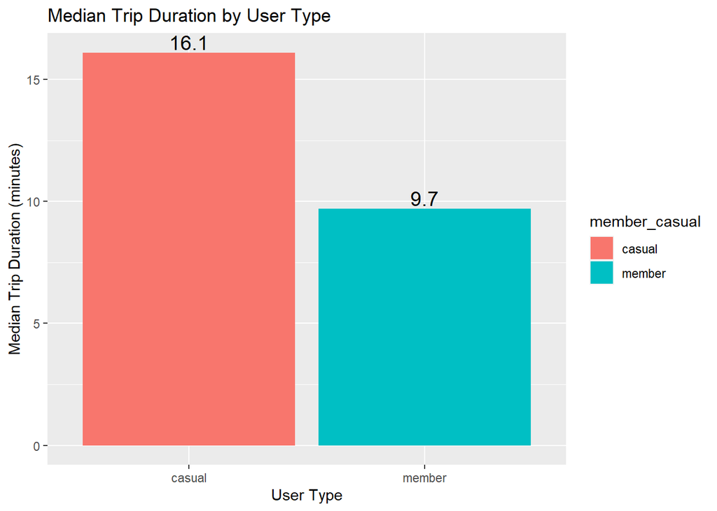

```r
tripdata_2021_v3 %>%
  group_by(member_casual) %>%
  summarise(median_duration = median(trip_duration)) %>%
  ggplot(aes(x = member_casual, y = median_duration, fill = member_casual ))+
  geom_col()+
  labs(title = "Median Trip Duration by User Type", x = "User Type", y = "Median Trip Duration (minutes)")+
  geom_text(aes(label = median_duration), vjust = -0.2, size =5)
```

Visualize the average trip duration by user type.

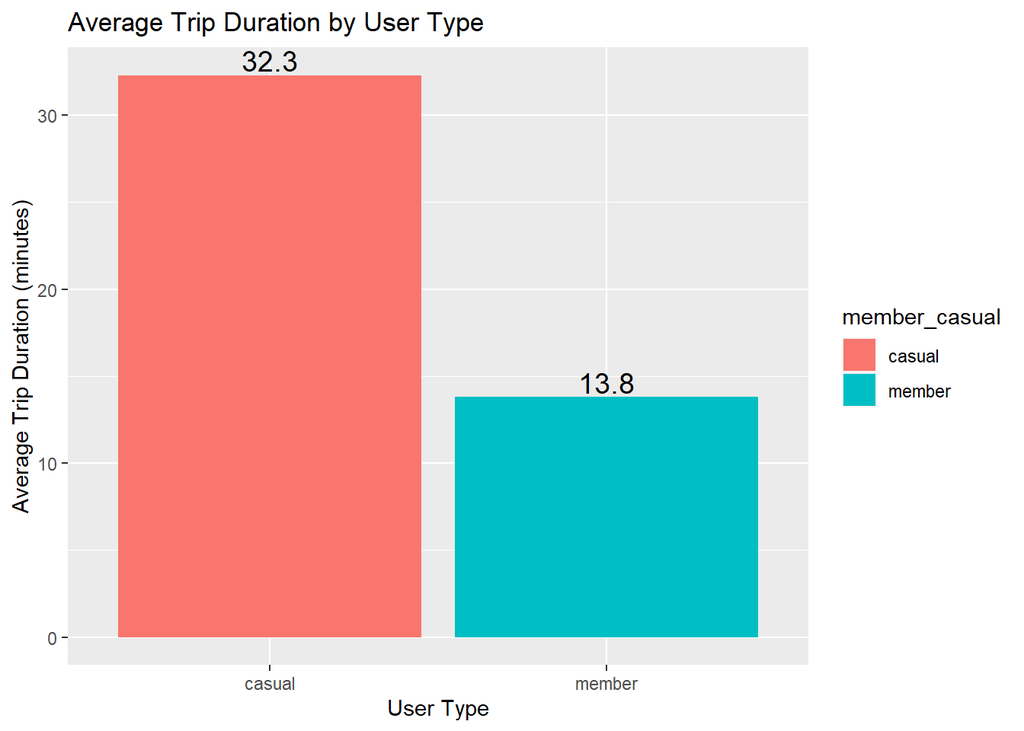

```r
tripdata_2021_v3 %>%
  group_by(member_casual) %>%
  summarise(avg_duration = round(mean(trip_duration),digits = 1)) %>%
  ggplot(aes(x = member_casual, y = avg_duration, fill = member_casual))+
  geom_col()+
  labs(title = "Average Trip Duration by User Type",x = "User Type", y = "Average Trip Duration (minutes)")+
  geom_text(aes(label = avg_duration), vjust = -0.2, size = 5)
```

### Key Finding 1: Casual users ride longer distant than members

- Casual users ride significantly long than members
- Maximum trip duration is 39 days, 35 times longer than members
- Median trip duration is 16 minutes, 66% longer than members
- Average trip duration is 32 minutes, 134% longer than members

**Questions to further investigate:** Why casual users chose a bike over a more efficient vehicle like car for trips that take up to 30 minutes?

Visualize the number of rides by day with user type.

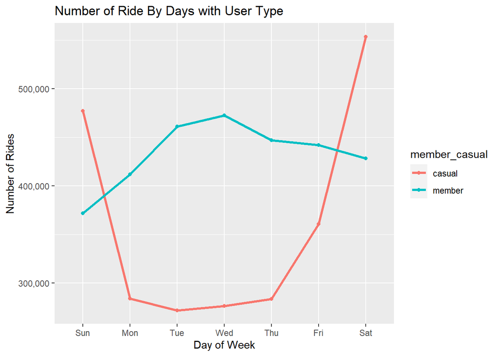

```r
tripdata_2021_v3 %>%
  group_by(member_casual, day_of_week) %>%
  summarise(number_of_rides = n(),
            mean_duration = round(mean(trip_duration), digits = 0)) %>%
  arrange(member_casual,day_of_week) %>%
  ggplot(aes(x=day_of_week,y=number_of_rides,group = member_casual))+
  geom_line(aes(color = member_casual),size = 1.2)+
  geom_point(aes(color = member_casual))+
  scale_y_continuous(name= "Number of Rides",labels = comma)+
  labs(title = "Number of Ride By Days with User Type", x= "Day of Week")
```

### Key Finding 2: Casual users are most active on weekends, members are most active on weekdays

Casual users’ rides are almost doubled on weekends, this represent 41% of the casual user annual rides, and the amount is more than members!

The pattern of members however, weekends’ rides are only 26% from total.

**Question to further investigate on casual user:**

1. **[Routine]** Could it be riding for long distance is not their routine in normal day to days, so paying for annual member fee just not worth the value?
2. **[Frequency]** How many of those casual users are first time user, how many of those are repeating users?
3. **[Inventory]** Are there enough bikes to ride during peak hours?

We couldn’t answer these questions due to the **data limitations** mentioned above, conduct survey would be a good idea here.

Visualize the average trip duration by user type with day of week.

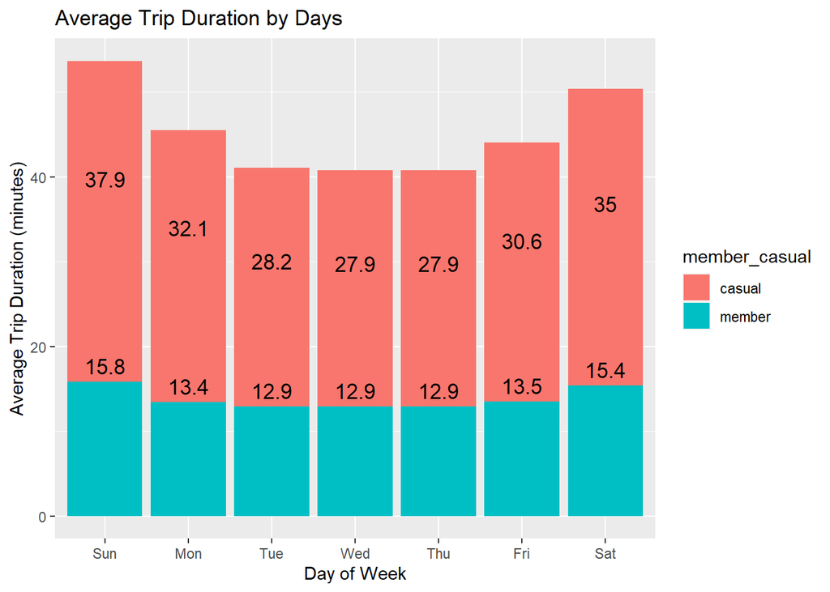

```r
tripdata_2021_v3 %>%
  group_by(member_casual, day_of_week) %>%
  summarise(avg_duration = round(mean(trip_duration), digits = 1)) %>%
  ggplot(aes(x = day_of_week, y = avg_duration, fill = member_casual))+
  geom_col()+
  labs(title = "Average Trip Duration by Days", x = "Day of Week", y = "Average Trip Duration (minutes)")+
  geom_text(aes(label = avg_duration), vjust = -0.5, size = 4.5)
```

Average trip duration for both user types is rather consistent throughout the whole week, **the closer to weekend the longer the duration**.

The average duration for members is very consistent at around 13 minutes on weekdays, this might be members use bike more to commute while casual users use bike for leisure purposes, will deep dive more details to find out.

Let’s go further to visualize the trips started time on weekdays.

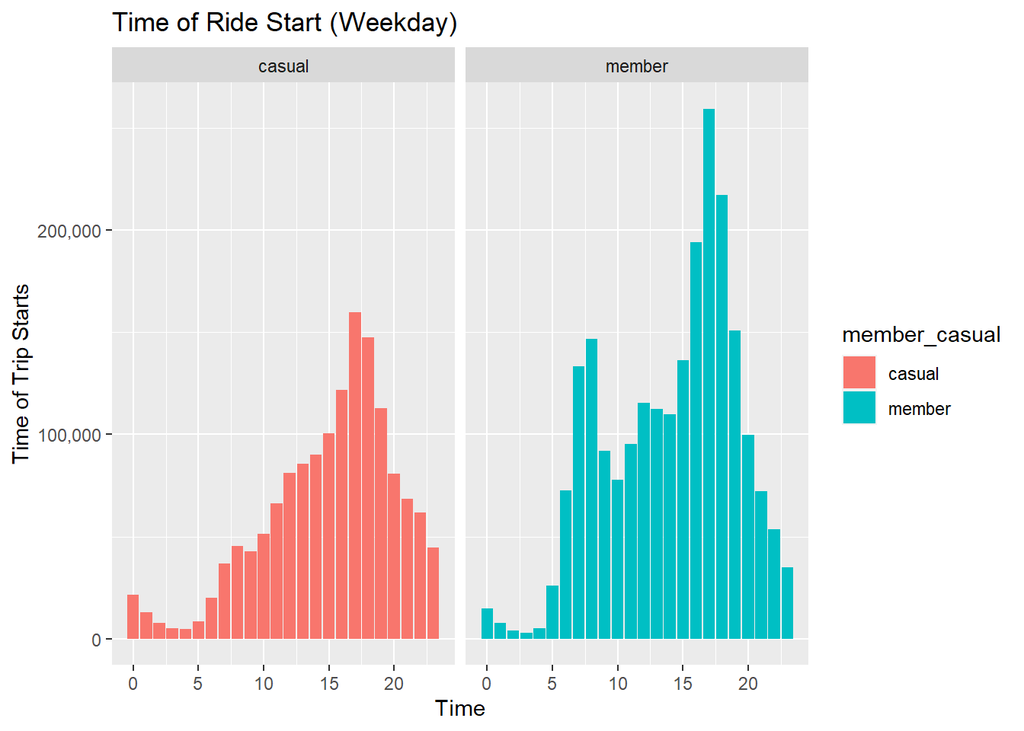

```r
tripdata_2021_v3 %>%
  group_by(member_casual, time_start) %>%
  filter(day_of_week != "Sat" & day_of_week != "Sun") %>%
  summarise(number_of_rides = n()) %>%
  ggplot(aes(x = time_start, y = number_of_rides, fill = member_casual))+
  geom_col()+
  facet_wrap(~member_casual)+
  scale_y_continuous(name = "Time of Trip Starts", labels = comma)+
  labs(title = "Time of Ride Start (Weekday)",x = "Time")
```

### Key Finding 3: Both user types are most active at 5pm weekday, but members are also very active at 8am

The closer to **5pm**, the more casual users ride, this could be going for cardio or having some fresh air after a long day of work.

Members are most active at **8am and 5pm**, could be riding to commute or some quick exercise before and after work.

Visualize the time of trip start on weekends.

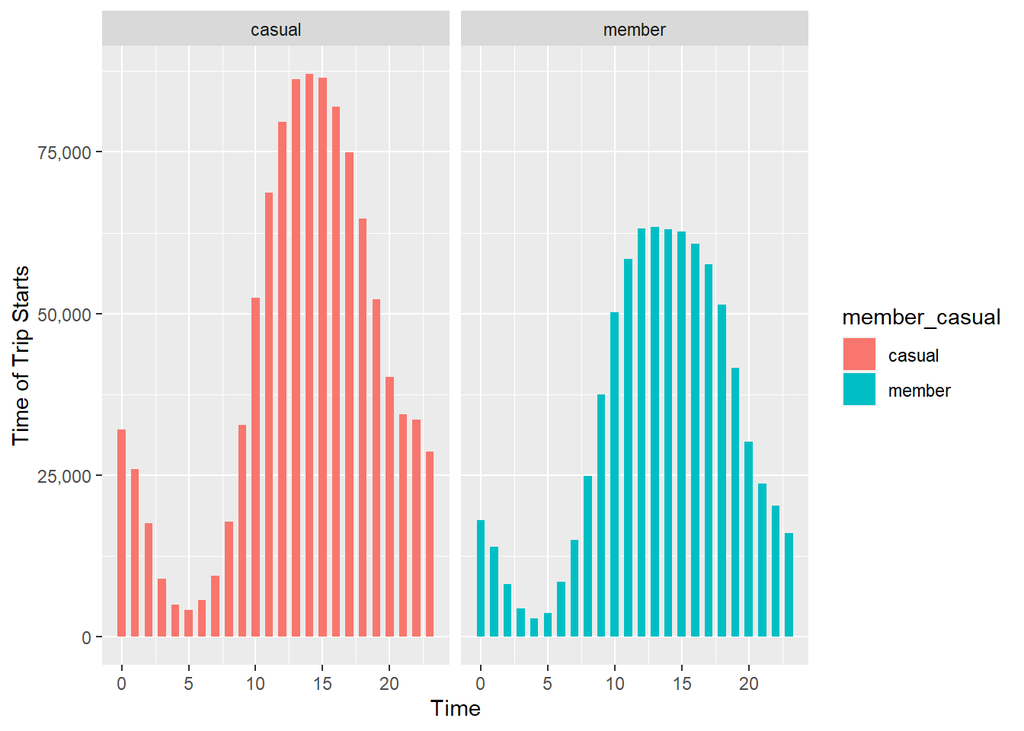

```r
tripdata_2021_v3 %>%
  group_by(member_casual, time_start) %>%
  filter(day_of_week == "Sat" | day_of_week == "Sun") %>%
  summarise(number_of_rides = n()) %>%
  ggplot(aes(x= time_start, y = number_of_rides, fill = member_casual))+
  geom_col(width = 0.6)+
  facet_wrap(~member_casual)+
  scale_y_continuous(name = "Time of Trip Starts", labels = comma)+
  labs(x = "Time")
```

### Key Finding 4: On weekend, both user types are most active during afternoon time

Majority of rides came **from 1pm to 3pm on weekends**, and **rides of casual users during this time is 37% more than members**!

Marketing team can be creative to strategise campaign for these hours.

Visualize the number of rides by month with user type.

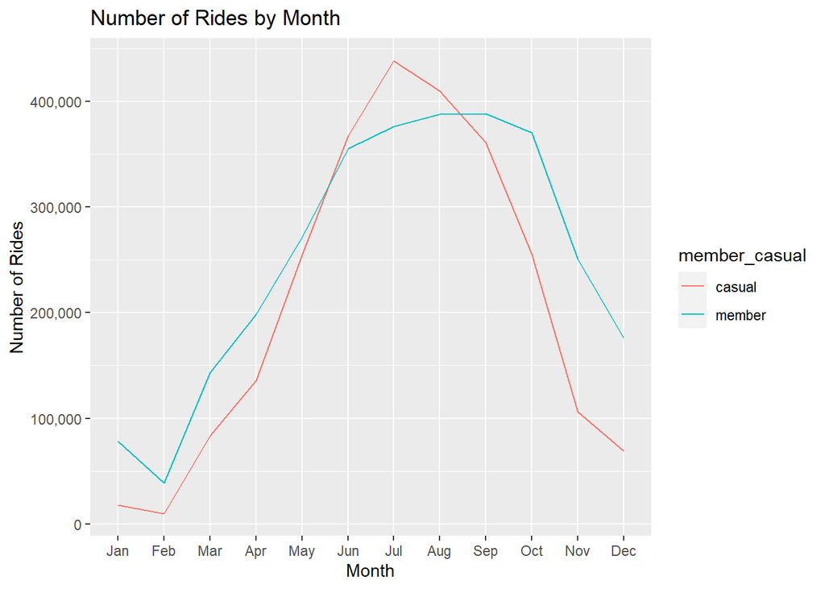

```r
tripdata_2021_v3 %>%
  group_by(member_casual, month_new) %>%
  summarise(number_of_rides = n()) %>%
  ggplot(aes(x = month_new, y = number_of_rides, group = member_casual))+
  geom_line(aes(color = member_casual), width = 2.0)+
  scale_y_continuous(name = "Number of Rides", labels = comma)+
  scale_x_discrete(limits = month.abb)+
  labs(title ="Number of Rides by Month", x = "Month")
```

### Key Finding 5: Summer Brings The Most Casual Users

I take the Chicago climate chart from NOAA for reference, we can see the higher the temperature the more riders ride.

The summer season from **June to August attract more casual users than members**, which is a very good time to engage more with casual riders.

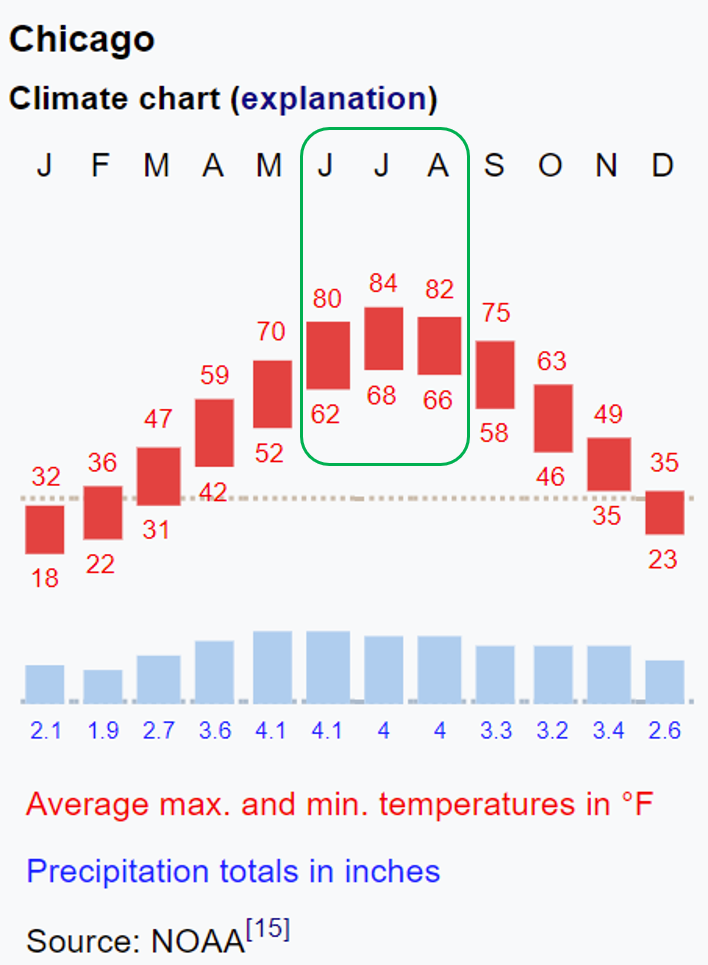

*Source: [National Weather Service](https://www.weather.gov/wrh/climate?wfo=lot)*

Finally, let’s explore if there is any impact on different bike types.

Visualize the number of rides by bike type with user type.

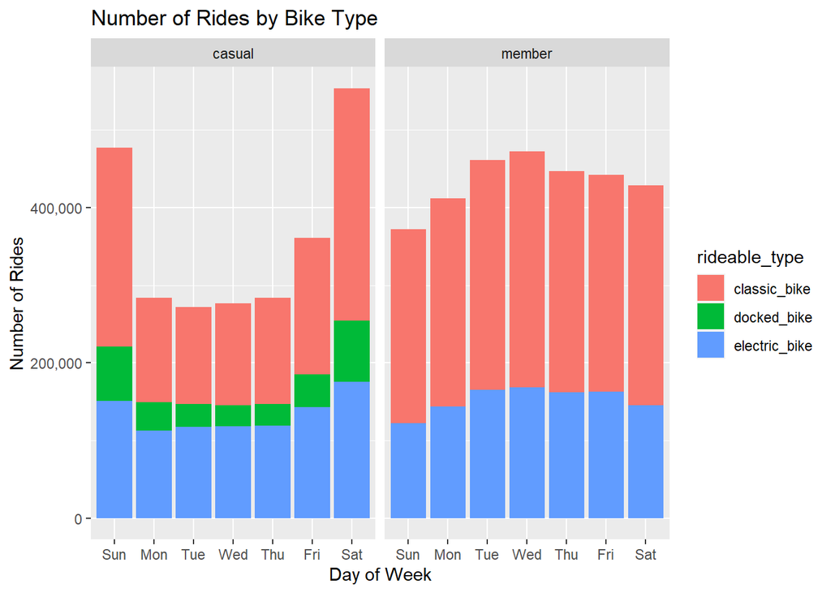

```r
tripdata_2021_v3 %>%
  group_by(member_casual, day_of_week, rideable_type) %>%
  summarise(number_of_rides = n()) %>%
  ggplot(aes(x = day_of_week, y = number_of_rides, fill = rideable_type))+
  geom_col()+
  facet_wrap(~member_casual)+
  scale_y_continuous(name = "Number of Rides", labels = comma)+
  labs(title = "Number of Rides by Bike Type", x = "Day of Week")
```

Visualize the number of rides by months with bike type.

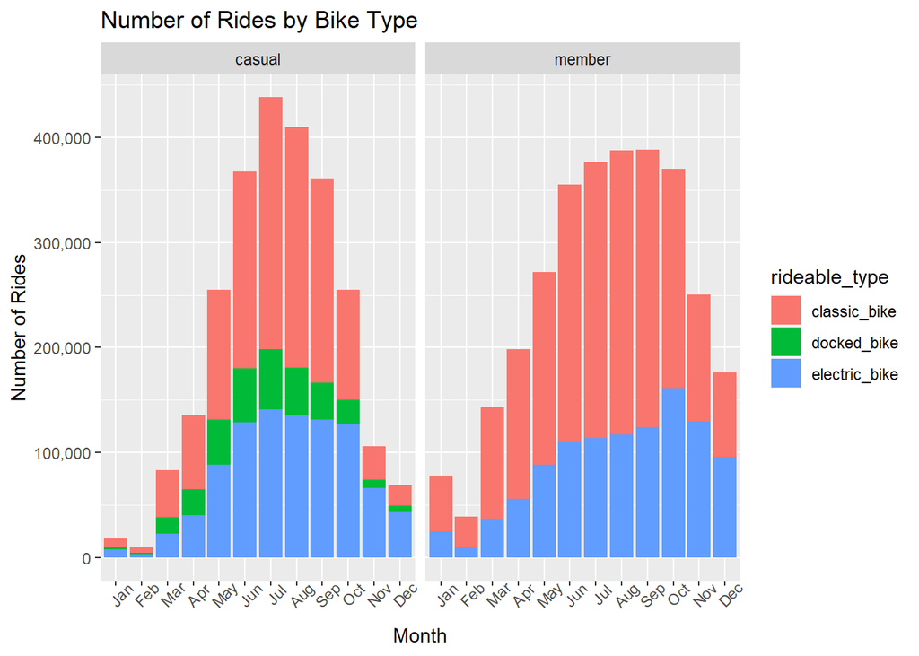

```r
tripdata_2021_v3 %>%
  group_by(member_casual, month_new, rideable_type) %>%
  summarise(number_of_rides = n()) %>%
  ggplot(aes(x = month_new, y = number_of_rides, fill = rideable_type))+
  geom_col()+
  facet_wrap(~member_casual)+
  scale_y_continuous(name = "Number of Rides", labels = comma)+
  scale_x_discrete(name = "Month", limits = month.abb)+
  theme(axis.text.x = element_text(angle = 45))+
  labs(title = "Number of Rides by Bike Type")
```

More casual riders enjoy taking classic bikes out on the weekends, this happened to members as well just the difference aren’t as obvious as casual riders.

An interesting fact is **members don’t use docked bikes**, only small group of casual riders do.

Looking for relationship between bike type and the trip duration for casual riders and members.

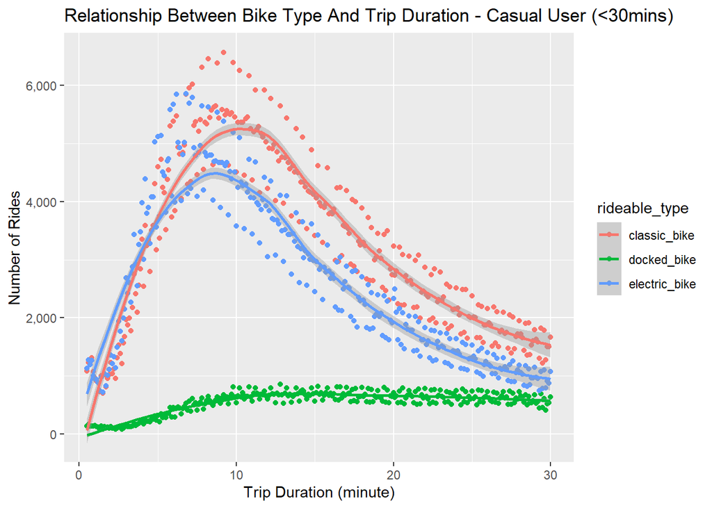

```r
#Trip duration less than 30 minutes
tripdata_2021_v3 %>%
  group_by(member_casual, rideable_type, trip_duration) %>%
  filter(member_casual == "casual", trip_duration <= 30) %>%
  summarise(number_of_rides = n()) %>%
  ggplot(aes(x= trip_duration, y = number_of_rides, color = rideable_type))+
  geom_point()+
  geom_smooth(method = "loess")+
  scale_y_continuous(name = "Number of Rides", labels = comma)+
  labs(title = "Relationship Between Bike Type And Trip Duration - Casual User (<30mins)", x= "Trip Duration (minute)")
```

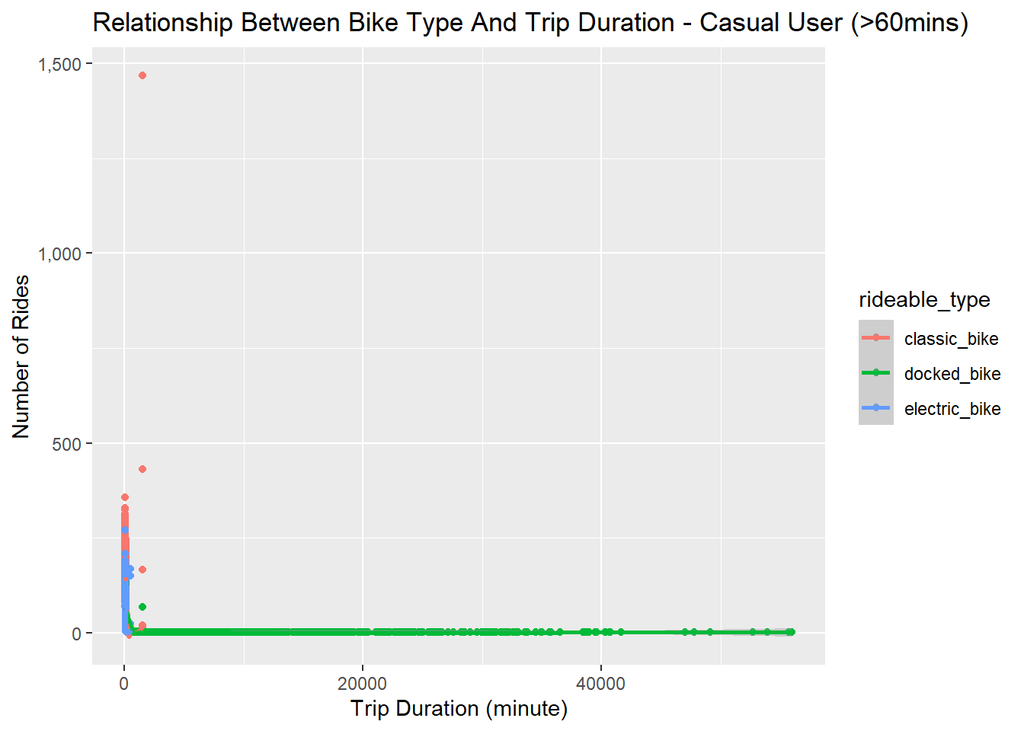

```r
#Trip duration greater than 1 hour
tripdata_2021_v3 %>%
  group_by(member_casual, rideable_type, trip_duration) %>%
  filter(member_casual == "casual", trip_duration >= 60) %>%
  summarise(number_of_rides = n()) %>%
  ggplot(aes(x= trip_duration, y = number_of_rides, color = rideable_type))+
  geom_point()+
  geom_smooth(method = "loess")+
  scale_y_continuous(name = "Number of Rides", labels = comma)+
  labs(title = "Relationship Between Bike Type And Trip Duration - Casual User (>60mins)", x= "Trip Duration (minute)")
```

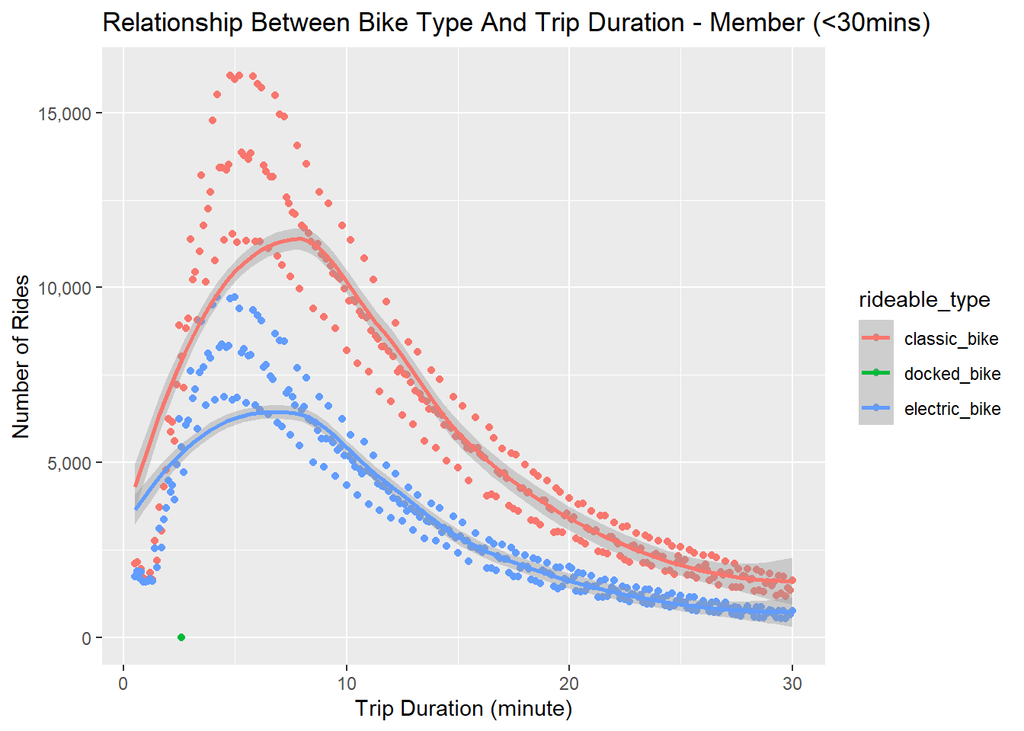

```r
tripdata_2021_v3 %>%
  group_by(member_casual, rideable_type, trip_duration) %>%
  filter(member_casual == "member", trip_duration <= 30) %>%
  summarise(number_of_rides = n()) %>%
  ggplot(aes(x= trip_duration, y = number_of_rides, color = rideable_type))+
  geom_point()+
  geom_smooth(method = "loess")+
  scale_y_continuous(name = "Number of Rides", labels = comma)+
  labs(title = "Relationship Between Bike Type And Trip Duration - Member (<30mins)", x= "Trip Duration (minute)")
```

There is no relationship between bike type and trip duration. Trips that are longer than 1 hour are mostly docked bike with no correlation between bike type and trip duration.

## 5. Summary of Analysis

How **members** and **casual users** use Cyclistic bikes differently?

### Trip duration

- The trip duration of casual users is 134% longer than members on average, which are 32 minutes and 14 minutes respectively

### Most active period

- Casual users are most active on weekends, total 41% of trips came from weekends
- Members are most active on weekdays, only 26% of trips came from weekends
- On weekdays, 5.00pm has the most casual users and members, but members are also actively riding at 8.00am in the morning
- On weekends, both casual users and members ride around 1.00pm to 3.00pm, but the rides of casual users are 37% more members
- Summer seasons brings the most casual users, even more than members

## 6. Recommendations

How marketing team could strategise marketing campaign base on this primary insights.

### 1.Begin with testing subscriptions that benefit riding on weekends

- 41% of total casual users’ trips came from weekends
- Take into consideration that they normally ride for 30 minutes long and are most active around 1-3pm on weekends
- Summer season is the best time to promote
- A/B testing on annual and seasons subscription pass, to compare which type convert more users

### 2.Collecting more data by motivating casual users register for an account

- Further analyze on individual usage to discover new insights
- Track user ride frequency and most common taken trips for future location targeting
- Track and measure user convertion rate

### 3.Do user survey on casual users to gain further insights

- Understand what is their primary purpose to ride
- Usually ride alone or with partners?
- Are they satisfied with our services?

## Thanks for reading this far!

I hope you enjoy this data exploration journey with me :)

If you have any questions regarding this case study or other questions for me, I am pleased to help.

You may reach me at zheeyao@gmail.com

May the data be with you!